# Introduction to R for RNA-Seq: Solutions

#### Exercise

Adapt the code above to create a density plot of the counts before filtering lowly expressed genes. How does it compare it to the density plot above?

```r
# density plot before
counts %>%
  ggplot(aes(x=count + 1, group=sample, color=condition)) +
  geom_density() +
  scale_x_log10()
```

[output not shown]

The large peak on the left of the plot shows that a large proportion of genes within each sample are not expressed or lowly-expressed.

#### Exercise

Adapt the code above to create box plots of the counts before scaling. How do they compare to the box plots above?

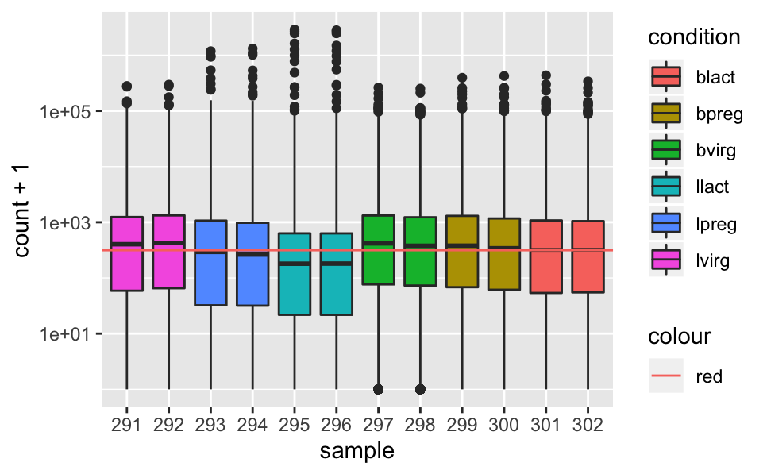

```r
# box plot before scaling
counts.norm %>%
  filter(lowly_abundant == FALSE) %>%
  ggplot(aes(x=sample, y=count + 1, fill=condition)) +
  geom_boxplot() +
  geom_hline(aes(yintercept = median(count + 1), colour = 'red')) +
  scale_y_log10()
```

#### Exercise

Colour the MDS plot with different metadata variables e.g. immunophenotype. Try using `shape=` inside the aes(). You can use ?geom_point to check the help page. Discuss what is the greatest source of variation in the data (i.e. what does dimension 1 represent)? What is the second greatest source of variation in the data?

Solution

```r
# MDS plot coloured by cell type
ggplot(MDSdims, aes(x=Dim1, y=Dim2, colour=condition)) +
  geom_point()
```

[output not shown]

```r
# MDS plot coloured by cell type
ggplot(MDSdims, aes(x=Dim1, y=Dim2, colour=immunophenotype)) +
  geom_point()
```

[output not shown]

```r
# MDS plot coloured by stage
ggplot(MDSdims, aes(x=Dim1, y=Dim2, colour=`developmental stage`)) +
  geom_point()
```

[output not shown]

```r
# MDS plot coloured by stage with shape for cell type
ggplot(MDSdims, aes(x=Dim1, y=Dim2, colour=`developmental stage`, shape=immunophenotype)) +
  geom_point()
```

[output not shown]

#### Exercise

Perform differential expression for lpreg vs llact Perform for 2 contrasts, bpreg vs blact and lpreg vs llact at the same time

#### Exercise

```r
counts.de %>%
  filter(FDR < 0.01 & abs(logFC) > 1) %>%
  heatmap(
        .horizontal = sample,
        .vertical = gene_symbol,
        .abundance = count_scaled,
        annotation = c(immunophenotype, `developmental stage`),
        log_transform = TRUE,
        palette_abundance = c("blue", "white", "red"),
        column_names_gp = gpar(fontsize = 8)
    )
```

[output not shown]